# Chapter 9 - functionals

Ian

2023-01-18

# 9.2.6 Exercises

## #1 Use as_mapper() to explore how purrr generates anonymous functions for the integer, character, and list helpers. What helper allows you to extract attributes? Read the documentation to find out.

```r
as_mapper(c("lorem", "ipsome", "dolor"))
```

```
## function (x, ...)
## pluck_raw(x, list("lorem", "ipsome", "dolor"), .default = NULL)
## <environment: 0x11aab8c18>
```

```r
as_mapper(c(1,2,3))
```

```
## function (x, ...)
## pluck_raw(x, list(1, 2, 3), .default = NULL)
## <environment: 0x104755f60>
```

```r
as_mapper(c("lorem", 2, "dolor"))
```

```
## function (x, ...)
## pluck_raw(x, list("lorem", "2", "dolor"), .default = NULL)
## <environment: 0x11aaf2be0>
```

`as_mapper()` uses `pluck_raw()` to assist it in extracting values.The `pluck()` function is a part of the `purrr` package in R. It is used to extract a value from a nested list or data frame by providing the key(s) or index(es) for the value you want to extract.

## #2 map(1:3, ~ runif(2)) is a useful pattern for generating random numbers, but map(1:3, runif(2)) is not. Why not? Can you explain why it returns the result that it does?

When using the ‘~’ operator the `runif()` function is called as an anonymous function, meaning it is called within `map()` without it, the `runif()` function is called before `map()` meaning each instance of `map()` being called will return the same list of 2 random numbers.

## #3 Use the appropriate map() function to:

#### Compute the standard deviation of every column in a numeric data frame.

```r
random_df <- data.frame(x = rnorm(10), y = rnorm(10), z = rnorm(10))
stddev <- map_dbl(random_df, sd)
print(stddev)
```

```
##         x         y         z
## 1.2440116 1.1038278 0.8819301
```

#### Compute the standard deviation of every numeric column in a mixed data frame. (Hint: you’ll need to do it in two steps.)

```r
random_df <- data.frame(x = rnorm(10), y = rnorm(10), z = rnorm(10),label = letters[1:10])
numeric_df <- select_if(random_df, is.numeric)
stddev <- map_dbl(numeric_df, sd)
print(stddev)
```

```
##         x         y         z
## 1.0081010 1.0944418 0.7843571
```

#### Compute the number of levels for every factor in a data frame.

```r
new_df <- data.frame(x = factor(letters[1:10]), y = factor(letters[11:20]))

# compute number of levels for each factor column
factored <- map_int(new_df, nlevels)
print(factored)
```

```
##  x  y
## 10 10
```

### #4 The following code simulates the performance of a t-test for non-normal data. Extract the p-value from each test, then visualise.

```r
trials <- map(1:100, ~ t.test(rpois(10, 10), rpois(7, 10)))
p_values <- map_dbl(trials, "p.value")
print(p_values)
```

```
##   [1] 0.7905760915 0.7694309035 0.5376434728 0.3116723581 0.0407455835
##   [6] 0.8509400740 0.6153670575 0.4719922752 0.7781182617 0.6795827130
##  [11] 0.2465266739 0.2074947719 0.4222288064 0.0840355735 0.7475395266
##  [16] 0.9927779324 0.9257224347 0.7280588666 0.9949799430 0.4489711061
##  [21] 0.5696753789 0.8760168247 0.2691273825 0.0327808918 0.1653345587
##  [26] 0.0239761031 0.6385655567 0.0932257899 0.3428814208 0.6040210696
##  [31] 0.5986989886 0.1476968181 0.8689739975 1.0000000000 0.5028171443
##  [36] 0.3980226926 0.3936340014 0.0353519945 0.8443775415 0.1377540847
##  [41] 0.8996999824 0.7942777601 0.3307564993 0.3838562563 0.3942510060
##  [46] 0.7164719293 0.5586266996 0.8062760085 0.5345015309 0.4768058307
##  [51] 0.6382087276 0.2432438158 0.2584287439 0.0573286051 0.4519164864
##  [56] 0.0003839287 0.5882761147 0.1012207546 0.3387657938 0.2794056731
##  [61] 0.7111060007 0.6429871485 0.1594582040 0.0797221286 0.4667504693
##  [66] 0.6794256966 0.6014154951 0.6107948851 0.0435685104 0.1426743908
##  [71] 0.8110998975 0.7867334405 0.9943177383 0.9426394046 0.5622185687
##  [76] 0.6342880016 0.3031729251 0.3373004097 0.2276478953 0.1066981383
##  [81] 0.2875127898 0.7126262642 0.2814711996 0.9340089750 0.3129951467
##  [86] 0.5729878155 0.1607326819 0.8531708532 0.8687650709 0.6673510840
##  [91] 0.6465116277 0.5630771612 0.1445277893 0.4615807512 0.5390495691
##  [96] 0.0776313290 0.7850653935 0.2731290390 0.1423713772 0.6110103980
```

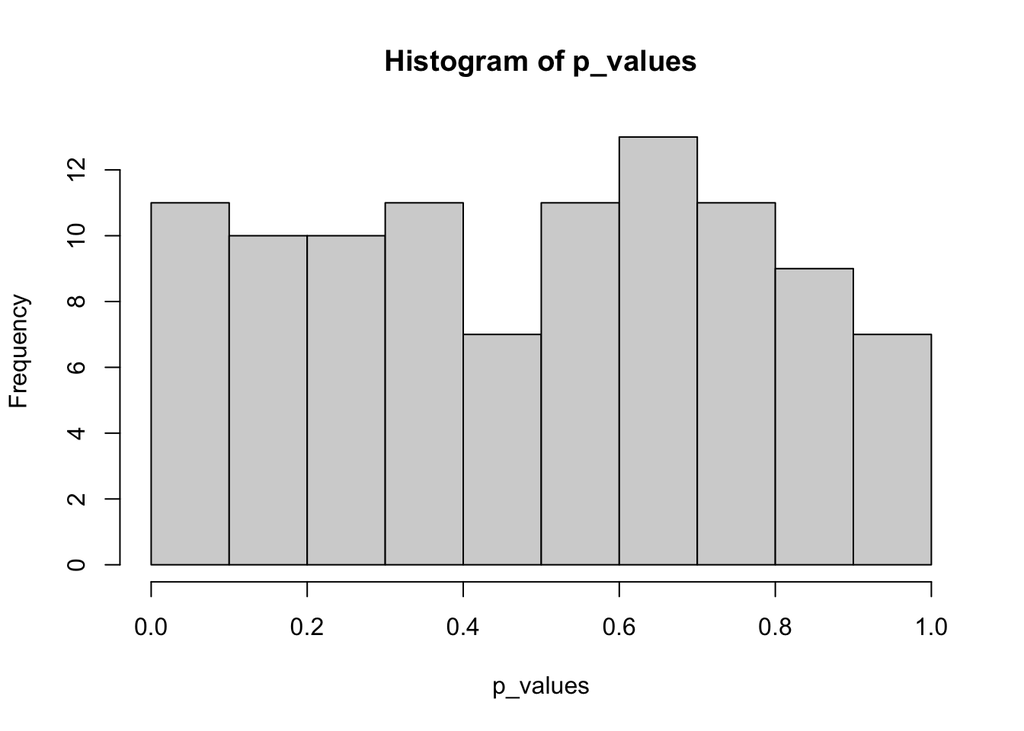

```r
hist(p_values)
```

## #2 Rewrite the following code to use iwalk() instead of walk2(). What are the advantages and disadvantages?

#### cyls <- split(mtcars, mtcars$cyl)

#### paths <- file.path(temp, paste0(“cyl-”, names(cyls), “.csv”))

#### walk2(cyls, paths, write.csv)

```r
#cyls <- split(mtcars, mtcars$cyl)
#paths <- file.path(temp, paste0("cyl-", names(cyls), ".csv"))
#iwalk(cyls, ~write.csv(.x, file = .y))
```

Advantages of using `iwalk()`:

- The code is more readable, since the function and its arguments are specified in a more explicit way.
- It allows you to use variable and formula input.
- It’s more flexible than walk2 and walk, it allows you to apply different functions to different elements. Disadvantages of using `iwalk()`:
- It can be more complex to understand and use, particularly if you are not familiar with the “tidy evaluation” approach.
- It can be less efficient than walk2 for some operations, as it requires more overhead to process the function and its arguments.

I don’t think `iwalk()` is actually better in this situation.

## #3 Explain how the following code transforms a data frame using functions stored in a list.

### disp = function(x) x * 0.0163871,

### am = function(x) factor(x, labels = c(“auto”, “manual”))

### mtcars[nm] <- map2(trans, mtcars[nm], function(f, var) f(var))

### Compare and contrast the map2() approach to this map() approach:

### mtcars[nm] <- map(nm, ~ trans[.x])

The code uses a `list` called `trans` to store two `functions`, one to transform the `disp` variable and another to transform the `am` variable. The `map2()` function is then used to apply these functions to the corresponding variables in the `mtcars` data frame.

## #4 What does write.csv() return, i.e. what happens if you use it with map2() instead of walk2()?

If you use `write.csv()` with `map2()` instead of `walk2()`, the `map2()` function will apply `write.csv()` to each element of two lists, but since `write.csv()` returns NULL, the output of `map2()` will be a list of NULL values.

This means that `map2()` will execute the `write.csv()` function for each element of the two lists and write the data frame to a CSV file, but it won’t return any value or output that you can use in your R script.